# Structure, prevalence and probability of correct identification

Еще раз привет!

В прошлом файле была информация о том, как распределена вероятность встретить Т-морфотип в двумерном поле Structure vs Prevalence. По мотивам этого анализа сразу встала идея посмотреть, а как в этом поле ведет себя вероятность правильного определения вида по морфотипу. И вот что получилось.

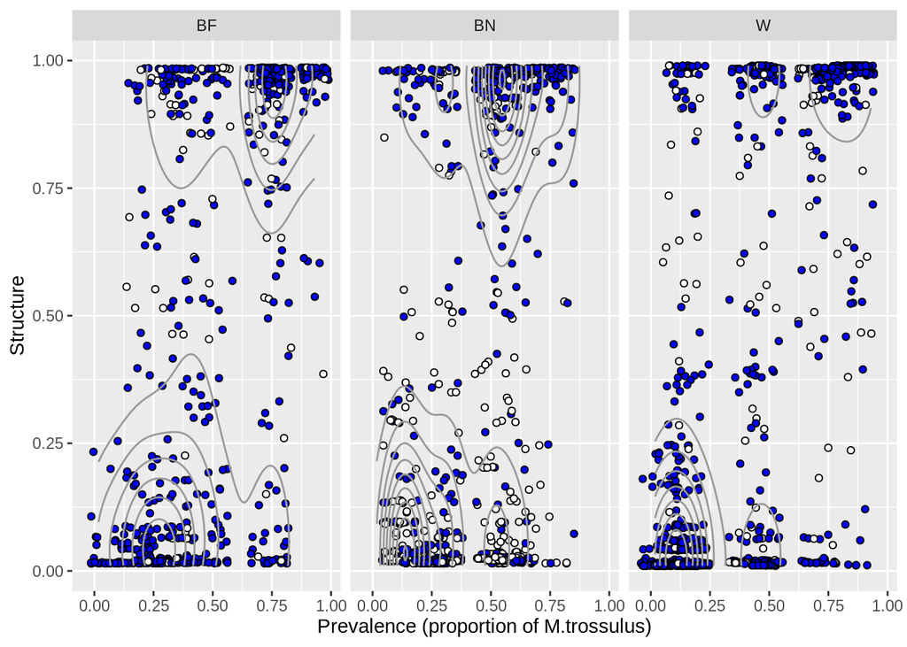

Можно усилить эту картинку, раскрасив поле Structure vs Prevalence с помощью GAM, которая будет отражать связь вероятности встретить правильно определенную мидию в зависимости от Structure, Pevalence и Area.

Модель здесь будет аналогична тому, что было в прошлом файле, только зависимая переменная будет другая.

$$P_{correct} = s[(Structure, Prevalence): Area] + Area + \varepsilon$$

визуализация данной модели будет это выглядеть вот так.

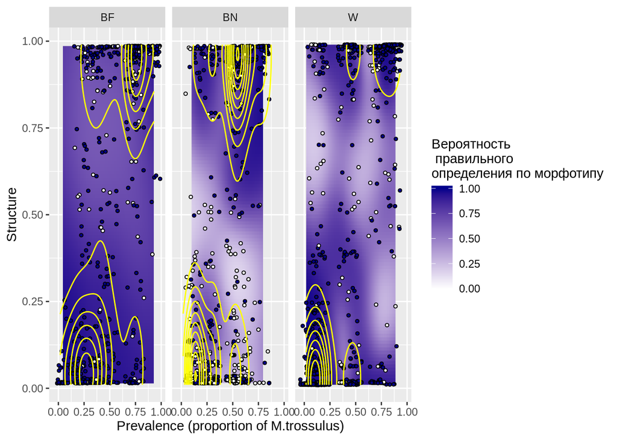

Та же самая картинка, но без точек, соответствующих отдельным мидиям.

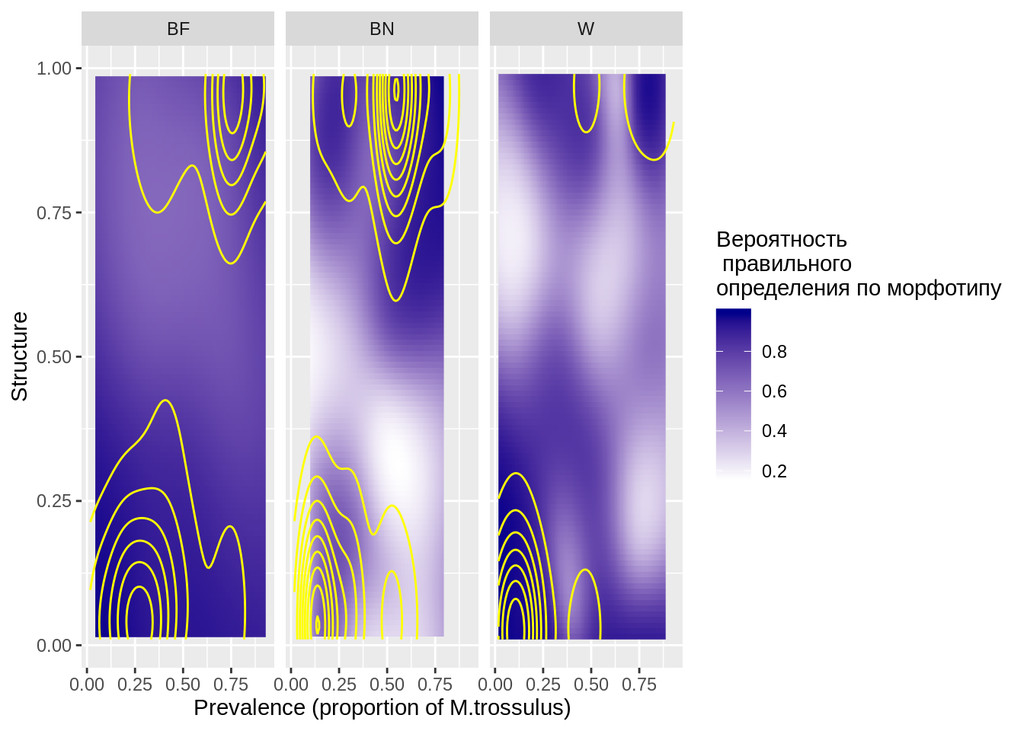

Таки, да! Получается, что вероятность правильной идентификации минимальна у гибридов и минорных генотипов.

Здесь видно, что в опресненном Баренцевом море признак работает почти везде (светлая область почти не выделяется).

В Белом море он работает в чистых поселениях, но только для мажорных генотипов или в смешанных для любых генотипов. Однако в Белом море этот признак плохо работает для гибридов (второго поколения?). При этом у эдулисных гибридов (Structure<0.5) в популяциях, где много эдулисов (Prevalence ~ 0) определение работает нормально. А вот у троссулусных гибридов (Structure>0.5) везде правильность идентификации хромает. Эдулисные гены все портят?

В Баренцевом море с нормальной соленостью похожая картинка. Однако в отношении гибридов она как бы противоположна Белому морю, как бы наоборот: эдулисные гибриды определяются плохо, зато троссулусные гибриды - хорошо. Троссулусные гены все портят?

Я бы подобную картинку в статью засунул, в конец. Она хороша!

Да, важное замечание. Во всех этих картинках использованы оба датасета (training + testing)